# Sta112FS 17. CLT based inference, Pt. 2

November 5, 2015

## Today's agenda

## Today's agenda

- CLT
- Inference for a mean
- Inference for difference in two means
- **Due Thursday:** HW 3 (will be emailed after class)

## Central Limit Theorem

## In practice…

- We can't construct sampling distributions directly, because we don't have access to the entire population data
  - this is the whole point of statistical inference: observe only one sample, try to make inference about the entire population
- Hence we rely on the **Central Limit Theorem** to tell us what the sampling distribution would look like, if we could construct it

## Central Limit Theorem

If certain conditions are met, the sampling distribution of the sample statistic will be nearly normally distributed with mean equal to the population parameter and standard error equal inversely proportional to the sample size.

- **Single mean:** \(\bar{x} \sim N\left(mean = \mu, SE = \frac{\sigma}{\sqrt{n}}\right)\)
- **Difference between two means:** \((\bar{x}_1 - \bar{x}_2) \sim N\left(mean = (\mu_1 - \mu_2), SE = \sqrt{\frac{s_1^2}{n_1} + \frac{s_2^2}{n_2}} \right)\)
- **Single proportion:** \(\hat{p} \sim N\left(mean = p, SE = \sqrt{\frac{p (1-p)}{n}} \right)\)
- **Difference between two proportions:** \((\hat{p}_1 - \hat{p}_2) \sim N\left(mean = (p_1 - p_2), SE = \sqrt{\frac{p_1 (1-p_1)}{n_1} + \frac{p_2(1-p_2)}{n_2}} \right)\)

## Conditions:

- **Independence:** The sampled observations must be independent. This is difficult to check, but the following are useful guidelines:
  - the sample must be random
  - if sampling without replacement, sample size must be less than 10% of population size
- **Sample size / distribution:**
  - numerical data: The more skewed the sample (and hence the population) distribution, the larger samples we need. Usually n > 30 is considered a large enough sample for population distributions that are not extremely skewed.
  - categorical data: At least 10 successes and 10 failures.
- If comparing two populations, the samples must be independent of each other, and all conditions should be checked for both groups.

## Inference methods based on CLT

## Inference methods based on CLT

If necessary conditions are met, we can also use inference methods based on the CLT:

- use the CLT to calculate the SE of the sample statistic of interest (sample mean, sample proportion, difference between sample means, etc.)
- calculate the **test statistic**, number of standard errors away from the null value the observed sample statistic is
  - T for means, along with appropriate degrees of freedom
  - Z for proportions
- use the test statistic to calculte the **p-value**, the probability of an observed or more extreme outcome given that the null hypothesis is true

## Z and T distributions

## Z distribution

- Also called the **standard normal distribution**: \(Z \sim N(mean = 0, \sigma = 1)\)
- Finding probabilities under the normal curve:

```r
pnorm(-1.96)
```

```
## [1] 0.0249979
```

```r
pnorm(1.96, lower.tail = FALSE)
```

```
## [1] 0.0249979
```

- Finding cutoff values under the normal curve:

```r
qnorm(0.025)
```

```
## [1] -1.959964
```

```r
qnorm(0.975)
```

```
## [1] 1.959964
```

## T distribution

- Also unimodal and symmetric, and centered at 0
- Thicker tails than the normal distribution (to make up for additional variability introduced by using \(s\) instead of \(\sigma\) in calculation of the SE)
- Parameter: **degrees of freedom**
  - df for single mean: \(df = n - 1\)
  - df for comparing two means: \(df = min(n_1 - 1, n_2 - 1)\)

## T distribution (cont.)

- Finding probabilities under the t curve:

```r
pt(-1.96, df = 9)
```

```
## [1] 0.0408222
```

```r
pt(1.96, df = 9, lower.tail = FALSE)
```

```
## [1] 0.0408222
```

- Finding cutoff values under the normal curve:

```r
qt(0.025, df = 9)
```

```
## [1] -2.262157
```

```r
qt(0.975, df = 9)
```

```
## [1] 2.262157
```

## Examples

## General Social Survey

- Since 1972, the General Social Survey (GSS) has been monitoring societal change and studying the growing complexity of American society.
- The GSS aims to gather data on contemporary American society in order to
  - monitor and explain trends and constants in attitudes, behaviors, attributes;
  - examine the structure and functioning of society in general as well as the role played by relevant subgroups;
  - compare the US to other societies to place American society in comparative perspective and develop cross-national models of human society;
  - make high-quality data easily accessible to scholars, students, policy makers, and others, with minimal cost and waiting.
- GSS questions cover a diverse range of issues including national spending priorities, marijuana use, crime and punishment, race relations, quality of life, confidence in institutions, and sexual behavior.

## Data

2010 GSS:

```r
gss <- read.csv("https://stat.duke.edu/~mc301/data/gss2010.csv")
```

- Data dictionary at https://gssdataexplorer.norc.org/variables/vfilter
- Note that not all questions are asked every year

## Inference for a single mean

## Hypothesis testing for a mean

One of the questions on the survey is "After an average work day, about how many hours do you have to relax or pursue activities that you enjoy?". Do these data provide convincing evidence that Americans, on average, spend more than 3 hours per day relaxing? Note that the variable of interest in the dataset is `hrsrelax`.

```r
gss %>% filter(!is.na(hrsrelax)) %>%
  summarise(mean(hrsrelax), median(hrsrelax), sd(hrsrelax), length(hrsrelax))
```

```
##   mean(hrsrelax) median(hrsrelax) sd(hrsrelax) length(hrsrelax)
## 1       3.680243                3     2.629641             1154
```

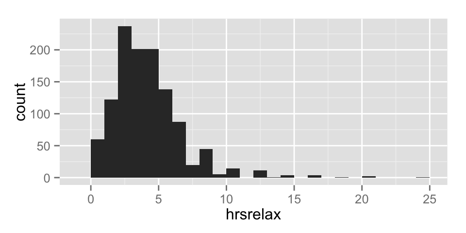

```r
ggplot(data = gss, aes(x = hrsrelax)) + geom_histogram(binwidth = 1)
```

## Hypotheses

What are the hypotheses for evaluation Americans, on average, spend more than 3 hours per day relaxing?

\[H_0: \mu = 3\] \[H_A: \mu > 3\]

## Conditions

1. Independence: The GSS uses a reasonably random sample, and the sample size of 1,154 is less than 10% of the US population, so we can assume that the respondents in this sample are independent of each other.
2. Sample size / skew: The distribution of hours relaxed is right skewed, however the sample size is large enough for the sampling distribution to be nearly normal.

## Calculating the test statistic

\[\bar{x} \sim N\left(mean = \mu, SE = \frac{s}{\sqrt{n}}\right)\] \[T_{df} = \frac{obs - null}{SE}\] \[df = n - 1\]

```r
# summary stats
hrsrelax_summ <- gss %>%
  filter(!is.na(hrsrelax)) %>%
  summarise(xbar = mean(hrsrelax), s = sd(hrsrelax), n = length(hrsrelax))
```

```r
# calculations
se <- hrsrelax_summ$s / sqrt(hrsrelax_summ$n)
t <- (hrsrelax_summ$xbar - 3) / se
df <- hrsrelax_summ$n - 1
```

## p-value

p-value = P(observed or more extreme outcome | \(H_0\) true)

```r
pt(t, df, lower.tail = FALSE)
```

```
## [1] 2.720895e-18
```

## Conclusion

- Since the p-value is small, we reject \(H_0\).
- The data provide convincing evidence that Americans, on average, spend more than 3 hours per day relaxing after work.

Would you expect a 90% confidence interval for the average number of hours Americans spend relaxing after work to include 3 hours?

## Confidence interval for a mean

\[point~estimate \pm critical~value \times SE\]

```r
t_star <- qt(0.95, df)
pt_est <- hrsrelax_summ$xbar
round(pt_est + c(-1,1) * t_star * se, 2)
```

```
## [1] 3.55 3.81
```

Interpret this interval in context of the data.

## In R

```r
# HT
t.test(gss$hrsrelax, mu = 3, alternative = "greater")
```

```
##
##  One Sample t-test
##
## data:  gss$hrsrelax
## t = 8.7876, df = 1153, p-value < 2.2e-16
## alternative hypothesis: true mean is greater than 3
## 95 percent confidence interval:
##  3.552813      Inf
## sample estimates:
## mean of x
##  3.680243
```

```r
# CI
t.test(gss$hrsrelax, conf.level = 0.90)$conf.int
```

```
## [1] 3.552813 3.807672
## attr(,"conf.level")
## [1] 0.9
```

## Aside: confidence vs. significance levels

## Equivalency of confidence and significance levels

- Two sided alternative HT with \(\alpha\) \(\rightarrow\) \(CL = 1 - \alpha\)
- One sided alternative HT with \(\alpha\) \(\rightarrow\) \(CL = 1 - (2 times \alpha)\)

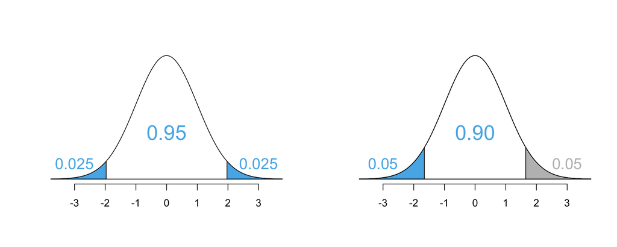

## Inference for difference of two means

## Hypothesis testing for a difference of two means

Is there a difference between the average number of hours relaxing after work between males and females. What are the hypotheses?

\[H_0: \mu_{M} = \mu_{F}\] \[H_A: \mu_{M} \ne \mu_{F}\]

Note that the variable identifying males and females in the dataset is `sex`.

## Exploratory analysis

What type of visualization would be appropriate for evaluating this research question?

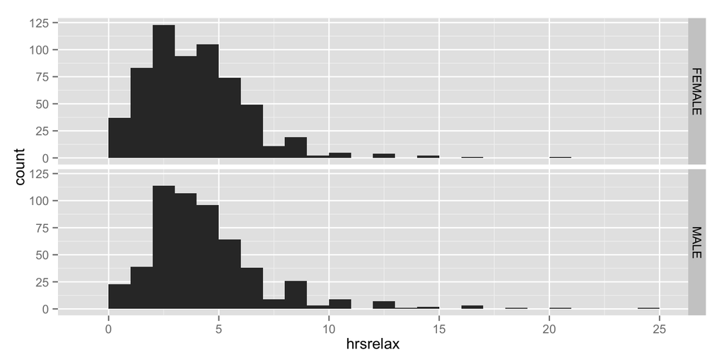

## Summary statistics

```r
hrsrelax_sex_summ <- gss %>%
  filter(!is.na(hrsrelax)) %>%
  group_by(sex) %>%
  summarise(xbar = mean(hrsrelax), s = sd(hrsrelax), n = length(hrsrelax))
hrsrelax_sex_summ
```

```
## Source: local data frame [2 x 4]
##
##      sex     xbar        s     n
##   (fctr)    (dbl)    (dbl) (int)
## 1 FEMALE 3.449180 2.396948   610
## 2   MALE 3.939338 2.848216   544
```

## Calculating the test statistic

\[(\bar{x}_1 - \bar{x}_2) \sim N\left(mean = (\mu_1 - \mu_2), SE = \sqrt{\frac{s_1^2}{n_1} + \frac{s_2^2}{n_2}} \right)\] \[T_{df} = \frac{obs - null}{SE}\] \[df = min(n_1 - 1, n_2 - 1)\]

```r
se <- sqrt((hrsrelax_sex_summ$s[1]^2 / hrsrelax_sex_summ$n[1])
           + (hrsrelax_sex_summ$s[2]^2 / hrsrelax_sex_summ$n[2]))
t <- ((hrsrelax_sex_summ$xbar[1] - hrsrelax_sex_summ$xbar[2]) - 0) / se
df <- min(hrsrelax_sex_summ$n[1], hrsrelax_sex_summ$n[2]) - 1
```

## p-value

p-value = P(observed or more extreme outcome | \(H_0\) true)

```r
pt(t, df) * 2
```

```
## [1] 0.001767347
```

Assuming \(\alpha = 0.05\), what is the conclusion of the hypothesis test?

## Equivalency to a confidence interval

What is the equivalent confidence level to this hypothesis test? At this level would you expect a confidence interval to include the difference in average number of hours relaxed by all American males and females?

## Confidence interval for a difference in means

\[point~estimate \pm critical~value \times SE\]

```r
t_star <- qt(0.975, df)
pt_est <- hrsrelax_sex_summ$xbar[1] - hrsrelax_sex_summ$xbar[2]
round(pt_est + c(-1,1) * t_star * se, 2)
```

```
## [1] -0.80 -0.18
```

Interpret this interval in context of the data. Make sure to indicate which group has a higher/lower mean in your interpretation.

## In R

Note that `t.test` function uses an exact degrees of freedom formula.

```r
# HT
t.test(gss$hrsrelax ~ gss$sex, mu = 0, alternative = "two.sided")
```

```
##
##  Welch Two Sample t-test
##
## data:  gss$hrsrelax by gss$sex
## t = -3.1424, df = 1066.3, p-value = 0.001722
## alternative hypothesis: true difference in means is not equal to 0
## 95 percent confidence interval:
##  -0.7962283 -0.1840875
## sample estimates:
## mean in group FEMALE   mean in group MALE
##             3.449180             3.939338
```

```r
# CI
t.test(gss$hrsrelax ~ gss$sex)$conf.int
```

```
## [1] -0.7962283 -0.1840875
## attr(,"conf.level")
## [1] 0.95
```